# ML_Project

## Importing Required Libraries

```python
import pandas as pd
import numpy as np
from scipy.stats import zscore
from sklearn.preprocessing import StandardScaler, LabelEncoder, OneHotEncoder
from sklearn.model_selection import train_test_split
from collections import Counter
import matplotlib.pyplot as plt
import seaborn as sns
from sklearn.ensemble import RandomForestClassifier, GradientBoostingClassifier
from sklearn.tree import DecisionTreeClassifier
import matplotlib.pyplot as plt
import seaborn as sns
import pandas as pd
import warnings
import os

from imblearn.over_sampling import RandomOverSampler
from sklearn.model_selection import train_test_split
from imblearn.over_sampling import RandomOverSampler
from sklearn.model_selection import train_test_split
from sklearn.neighbors import KNeighborsClassifier, LocalOutlierFactor
from sklearn.svm import SVC, OneClassSVM
from sklearn.covariance import EllipticEnvelope
from sklearn.ensemble import IsolationForest, VotingClassifier
from sklearn.impute import SimpleImputer
from sklearn.compose import ColumnTransformer
from sklearn.pipeline import Pipeline
from sklearn.decomposition import PCA
from sklearn.manifold import TSNE
from sklearn.metrics import classification_report, accuracy_score, confusion_matrix


warnings.filterwarnings("ignore")
```

## Reading dataset

```python
# path to our CSV file
csv_file_path = r"combined_file.csv"

# Read the CSV file into a Pandas DataFrame
tf_df = pd.read_csv(csv_file_path)
target_column = ' Label'
```

## EDA

### Basic information about our data set

```python
# Display the first 5 rows of the DataFrame
tf_df.head()
```

|  | Destination Port | Flow Duration | Total Fwd Packets | Total Backward Packets | Total Length of Fwd Packets | Total Length of Bwd Packets | Fwd Packet Length Max | Fwd Packet Length Min | Fwd Packet Length Mean | Fwd Packet Length Std | ... | Active Max | Active Min | Idle Mean | Idle Std | Idle Max | Idle Min | Label | ipv4 | Label | date |
| --- | --- | --- | --- | --- | --- | --- | --- | --- | --- | --- | --- | --- | --- | --- | --- | --- | --- | --- | --- | --- | --- |
| 0 | 54865.0 | 3.0 | 2.0 | 0.0 | 12.0 | 0.0 | 6.0 | 6.0 | 6.0 | 0.0 | ... | 0.0 | 0.0 | 0.0 | 0.0 | 0.0 | 0.0 | BENIGN | NaN | NaN | NaN |
| 1 | 55054.0 | 109.0 | 1.0 | 1.0 | 6.0 | 6.0 | 6.0 | 6.0 | 6.0 | 0.0 | ... | 0.0 | 0.0 | 0.0 | 0.0 | 0.0 | 0.0 | BENIGN | NaN | NaN | NaN |
| 2 | 55055.0 | 52.0 | 1.0 | 1.0 | 6.0 | 6.0 | 6.0 | 6.0 | 6.0 | 0.0 | ... | 0.0 | 0.0 | 0.0 | 0.0 | 0.0 | 0.0 | BENIGN | NaN | NaN | NaN |
| 3 | 46236.0 | 34.0 | 1.0 | 1.0 | 6.0 | 6.0 | 6.0 | 6.0 | 6.0 | 0.0 | ... | 0.0 | 0.0 | 0.0 | 0.0 | 0.0 | 0.0 | BENIGN | NaN | NaN | NaN |
| 4 | 54863.0 | 3.0 | 2.0 | 0.0 | 12.0 | 0.0 | 6.0 | 6.0 | 6.0 | 0.0 | ... | 0.0 | 0.0 | 0.0 | 0.0 | 0.0 | 0.0 | BENIGN | NaN | NaN | NaN |

5 rows × 82 columns

```python
#shape of the dataset
print('Number of data points: ',tf_df.shape[0])
print('Number of features: ', tf_df.shape[1])
```

```
Number of data points:  3033050
Number of features:  82
```

```python
# column names and their Datatypes
tf_df.info()
```

```
<class 'pandas.core.frame.DataFrame'>
RangeIndex: 3033050 entries, 0 to 3033049
Data columns (total 82 columns):
 #   Column                        Dtype
---  ------                        -----
 0    Destination Port             float64
 1    Flow Duration                float64
 2    Total Fwd Packets            float64
 3    Total Backward Packets       float64
 4   Total Length of Fwd Packets   float64
 5    Total Length of Bwd Packets  float64
 6    Fwd Packet Length Max        float64
 7    Fwd Packet Length Min        float64
 8    Fwd Packet Length Mean       float64
 9    Fwd Packet Length Std        float64
```

[output cut: 74 more lines]

```python
# number of unique values in each Column
tf_df.nunique()
```

```
 Destination Port                53805
 Flow Duration                 1050899
 Total Fwd Packets                1432
 Total Backward Packets           1747
Total Length of Fwd Packets      17928
                                ...
 Idle Min                       223888
 Label                              15
ipv4                             28901
Label                                1
date                                 7
Length: 82, dtype: int64
```

### Descriptive Statistics:

```python
# Let's see the statistics for numerical columns
tf_df.describe()
```

|  | Destination Port | Flow Duration | Total Fwd Packets | Total Backward Packets | Total Length of Fwd Packets | Total Length of Bwd Packets | Fwd Packet Length Max | Fwd Packet Length Min | Fwd Packet Length Mean | Fwd Packet Length Std | ... | act_data_pkt_fwd | min_seg_size_forward | Active Mean | Active Std | Active Max | Active Min | Idle Mean | Idle Std | Idle Max | Idle Min |
| --- | --- | --- | --- | --- | --- | --- | --- | --- | --- | --- | --- | --- | --- | --- | --- | --- | --- | --- | --- | --- | --- |
| count | 2.830743e+06 | 2.830743e+06 | 2.830743e+06 | 2.830743e+06 | 2.830743e+06 | 2.830743e+06 | 2.830743e+06 | 2.830743e+06 | 2.830743e+06 | 2.830743e+06 | ... | 2.830743e+06 | 2.830743e+06 | 2.830743e+06 | 2.830743e+06 | 2.830743e+06 | 2.830743e+06 | 2.830743e+06 | 2.830743e+06 | 2.830743e+06 | 2.830743e+06 |
| mean | 8.071483e+03 | 1.478566e+07 | 9.361160e+00 | 1.039377e+01 | 5.493024e+02 | 1.616264e+04 | 2.075999e+02 | 1.871366e+01 | 5.820194e+01 | 6.891013e+01 | ... | 5.418218e+00 | -2.741688e+03 | 8.155132e+04 | 4.113412e+04 | 1.531825e+05 | 5.829582e+04 | 8.316037e+06 | 5.038439e+05 | 8.695752e+06 | 7.920031e+06 |
| std | 1.828363e+04 | 3.365374e+07 | 7.496728e+02 | 9.973883e+02 | 9.993589e+03 | 2.263088e+06 | 7.171848e+02 | 6.033935e+01 | 1.860912e+02 | 2.811871e+02 | ... | 6.364257e+02 | 1.084989e+06 | 6.485999e+05 | 3.933815e+05 | 1.025825e+06 | 5.770923e+05 | 2.363008e+07 | 4.602984e+06 | 2.436689e+07 | 2.336342e+07 |
| min | 0.000000e+00 | -1.300000e+01 | 1.000000e+00 | 0.000000e+00 | 0.000000e+00 | 0.000000e+00 | 0.000000e+00 | 0.000000e+00 | 0.000000e+00 | 0.000000e+00 | ... | 0.000000e+00 | -5.368707e+08 | 0.000000e+00 | 0.000000e+00 | 0.000000e+00 | 0.000000e+00 | 0.000000e+00 | 0.000000e+00 | 0.000000e+00 | 0.000000e+00 |
| 25% | 5.300000e+01 | 1.550000e+02 | 2.000000e+00 | 1.000000e+00 | 1.200000e+01 | 0.000000e+00 | 6.000000e+00 | 0.000000e+00 | 6.000000e+00 | 0.000000e+00 | ... | 0.000000e+00 | 2.000000e+01 | 0.000000e+00 | 0.000000e+00 | 0.000000e+00 | 0.000000e+00 | 0.000000e+00 | 0.000000e+00 | 0.000000e+00 | 0.000000e+00 |
| 50% | 8.000000e+01 | 3.131600e+04 | 2.000000e+00 | 2.000000e+00 | 6.200000e+01 | 1.230000e+02 | 3.700000e+01 | 2.000000e+00 | 3.400000e+01 | 0.000000e+00 | ... | 1.000000e+00 | 2.400000e+01 | 0.000000e+00 | 0.000000e+00 | 0.000000e+00 | 0.000000e+00 | 0.000000e+00 | 0.000000e+00 | 0.000000e+00 | 0.000000e+00 |
| 75% | 4.430000e+02 | 3.204828e+06 | 5.000000e+00 | 4.000000e+00 | 1.870000e+02 | 4.820000e+02 | 8.100000e+01 | 3.600000e+01 | 5.000000e+01 | 2.616295e+01 | ... | 2.000000e+00 | 3.200000e+01 | 0.000000e+00 | 0.000000e+00 | 0.000000e+00 | 0.000000e+00 | 0.000000e+00 | 0.000000e+00 | 0.000000e+00 | 0.000000e+00 |
| max | 6.553500e+04 | 1.200000e+08 | 2.197590e+05 | 2.919220e+05 | 1.290000e+07 | 6.554530e+08 | 2.482000e+04 | 2.325000e+03 | 5.940857e+03 | 7.125597e+03 | ... | 2.135570e+05 | 1.380000e+02 | 1.100000e+08 | 7.420000e+07 | 1.100000e+08 | 1.100000e+08 | 1.200000e+08 | 7.690000e+07 | 1.200000e+08 | 1.200000e+08 |

8 rows × 78 columns

### Data Cleaning:

```python
# Function to check columns which have null or infinite values.
def Check_NUll_Infinite_Value():

    # Initialize lists to store columns with NaN or infinite values
    columns_with_nan = []
    columns_with_inf = []

    # Get all the numeric columns
    num_columns = tf_df.select_dtypes(include=[np.number]).columns

    # Check for NaN or Infinite values in each column
    for column in num_columns:
        if tf_df[column].isnull().any():
            columns_with_nan.append(column)

        if np.isinf(tf_df[column]).any():
            columns_with_inf.append(column)

    # Print the lists
    if columns_with_nan:
        print("Columns with NaN values:", columns_with_nan)
    else:
        print("No Columns have NaN values")
    if columns_with_inf:
        print("\n\nColumns with Infinite values:", columns_with_inf)
    else:
        print("\n\nNo Columns have infinite values")
```

```python
Check_NUll_Infinite_Value()
```

```
Columns with NaN values: [' Destination Port', ' Flow Duration', ' Total Fwd Packets', ' Total Backward Packets', 'Total Length of Fwd Packets', ' Total Length of Bwd Packets', ' Fwd Packet Length Max', ' Fwd Packet Length Min', ' Fwd Packet Length Mean', ' Fwd Packet Length Std', 'Bwd Packet Length…


Columns with Infinite values: ['Flow Bytes/s', ' Flow Packets/s']
```

```python
#Let's see count of null values for each column.
tf_df.isna().sum()
```

```
 Destination Port               202307
 Flow Duration                  202307
 Total Fwd Packets              202307
 Total Backward Packets         202307
Total Length of Fwd Packets     202307
                                ...
 Idle Min                       202307
 Label                          202307
ipv4                           2830743
Label                          2830743
date                           2830743
Length: 82, dtype: int64
```

Note:

If we check above output we can see that almost all columns have same number of null values. Let's check and drop the rows, which have more than 15 null values.

```python
# Count the number of rows with more than 15 null values in a row
null_counts_per_row = tf_df.isnull().sum(axis=1)
rows_with_more_than_six_nulls_count = (null_counts_per_row > 15).sum()
percentage_of_rows_with_more_than_six_nulls = (rows_with_more_than_six_nulls_count / len(tf_df)) * 100

# Print the count
print(f"Number of rows with more than 15 null values: {rows_with_more_than_six_nulls_count}")
print(f"Percentage of rows with more than 15 null values in the total dataset: {percentage_of_rows_with_more_than_six_nulls:.2f}%")
```

```
Number of rows with more than 15 null values: 202307
Percentage of rows with more than 15 null values in the total dataset: 6.67%
```

Since these rows have more than 15 null values out of 80 columns we are dropping them. We can fill the null values using mean, median, or mode but we choose to drop them. Because we have 3033050 records and these null value rows contain most of the values as null and their percentage is less than 10% in the whole dataset. It's better to drop them.

```python
# 1.Handling null values

#drop the empty columns
tf_df.drop(['ipv4','Label', 'date'],axis=1,inplace=True)

# Dropping null values
tf_df.dropna(inplace=True)
print("shape of dataset after dropping null values",tf_df.shape)
```

```
shape of dataset after dropping null values (2829385, 79)
```

```python
# 2. Handling infinite values

tf_df.replace([np.inf, -np.inf], np.finfo('float64').max, inplace=True)
```

```python
Check_NUll_Infinite_Value()
```

```
No Columns have NaN values


No Columns have infinite values
```

```python
print("Duplicate rows - ",tf_df.duplicated().sum())
```

```
Duplicate rows -  307376
```

```python
# 3. Handling Duplicate records

tf_df.drop_duplicates(keep='first', inplace=True)
print("Duplicate rows - ",tf_df.duplicated().sum())
```

```
Duplicate rows -  0
```

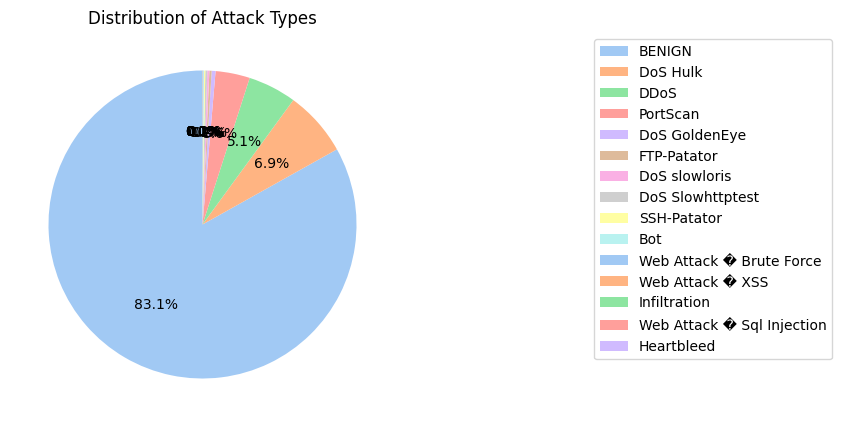

```python
# Check Distribution of Classes in Target(" Label") column

# calculate attack_counts from target column
attack_counts = tf_df[' Label'].value_counts()

# Set a color palette for the pie chart
colors = sns.color_palette('pastel')[0:len(attack_counts)]

# Create a pie chart
plt.figure(figsize=(5, 5))
plt.pie(attack_counts, labels=None, autopct='%1.1f%%', startangle=90, colors=colors)

# Add a legend with attack types and corresponding colors outside the plot
plt.legend(labels=attack_counts.index, loc='upper left', bbox_to_anchor=(1.5, 1))

plt.title('Distribution of Attack Types')
plt.show()
```

We can see that in out target column most of the data belongs to "BENIGN" category. We need to balance them(Here We have taken undersampling method) otherwise accuracy might misguided us.

Let's see why:

if a column has 2 classes(0 and 1):

out of 100 records

class 0 ha 95 records

and class 1 has 5 records.

In such cases if we return the prediction values (even without predicting) as class 0 we will get 95% accuracy. Which is not correct

```python
# 4. Balancing Class distribution in ' Label' Column.

#4.1 under sampling "BENING" class in ' Label' Column.

value_to_drop = 'BENIGN'
rows_to_drop = tf_df[tf_df[' Label'] == value_to_drop].sample(frac=0.85).index
tf_df = tf_df.drop(rows_to_drop)


# 4.2 dropping minor classes in " Label" column with less than 5000 records
value_counts = tf_df[' Label'].value_counts()

# check for labels with count values less than 5000
labels_to_drop  = value_counts[value_counts < 5000].index

tf_df = tf_df[~tf_df[' Label'].isin(labels_to_drop)]





# 4.3 oversample minor classes using RandomOverSampler

X = tf_df.drop(' Label', axis=1)
y = tf_df[' Label']

# Split the data into training and testing sets
X_train, X_test, y_train, y_test = train_test_split(X, y, test_size=0.2, random_state=42)

# Initialize RandomOverSampler
oversampler = RandomOverSampler(random_state=42)

# Fit and apply the random oversampler to the training data
X_resampled, y_resampled = oversampler.fit_resample(X_train, y_train)

# Create a DataFrame from the oversampled data
df_resampled = pd.concat([pd.DataFrame(X_resampled, columns=X_train.columns), pd.Series(y_resampled, name=' Label')], axis=1)

# Update the original DataFrame with the oversampled data
tf_df = pd.concat([tf_df, df_resampled])
```

### Vizulization

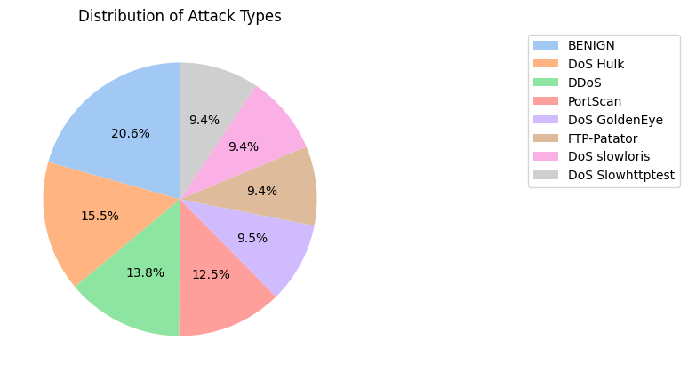

```python
#1. pichart representation for Distribution of classes in target column

# calculate attack_counts from target column
attack_counts = tf_df[' Label'].value_counts()

# Set a color palette for the pie chart
colors = sns.color_palette('pastel')[0:len(attack_counts)]

# Create a pie chart
plt.figure(figsize=(5, 5))
plt.pie(attack_counts, labels=None, autopct='%1.1f%%', startangle=90, colors=colors)

# Add a legend with attack types and corresponding colors outside the plot
plt.legend(labels=attack_counts.index, loc='upper left', bbox_to_anchor=(1.5, 1))

plt.title('Distribution of Attack Types')
plt.show()
```

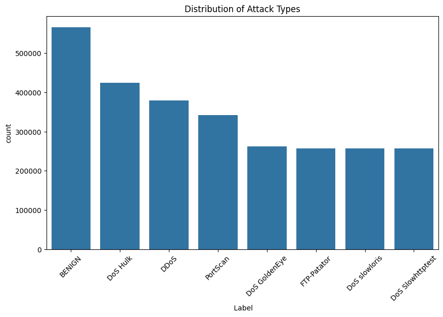

```python
#2. count plot representation for Distribution of classes in target column

plt.figure(figsize=(10, 6))
sns.countplot(x=' Label', data=tf_df, order=tf_df[' Label'].value_counts().index)
plt.title('Distribution of Attack Types')
plt.xticks(rotation=45)
plt.show()
```

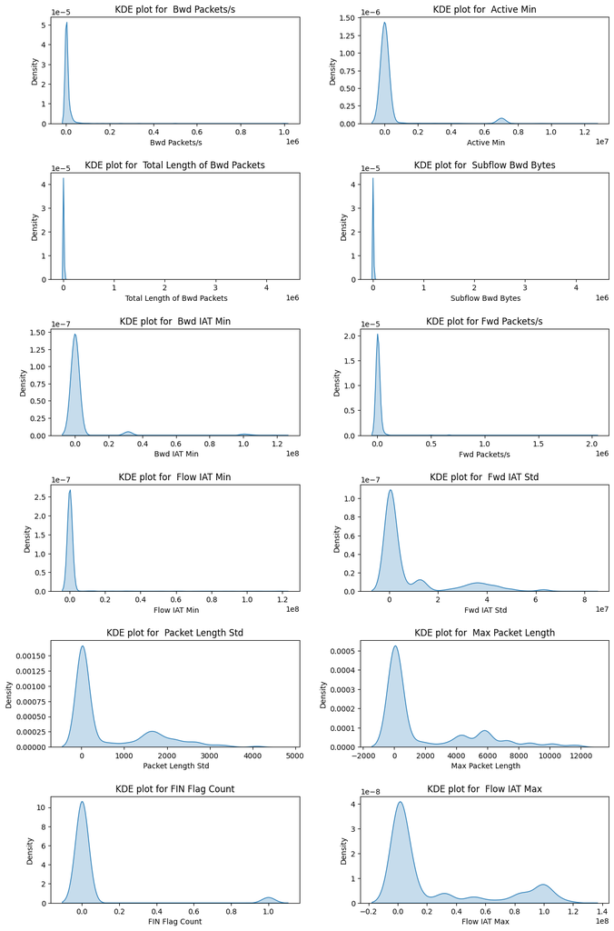

```python
# 3.KDE Plots to show the distribution of the columns

features_to_plot = [' Bwd Packets/s', ' Active Min', ' Total Length of Bwd Packets', ' Subflow Bwd Bytes', ' Bwd IAT Min', 'Fwd Packets/s', ' Flow IAT Min', ' Fwd IAT Std', ' Packet Length Std', ' Max Packet Length',  'FIN Flag Count', ' Flow IAT Max']

# Set up subplots
fig, axes = plt.subplots(nrows=len(features_to_plot)//2 + len(features_to_plot)%2, ncols=2, figsize=(12, 18))

# Flatten the 2D array of subplots
axes = axes.flatten()
dataa = tf_df.sample(n=10000, random_state=42)

# Plot histograms for each feature
for i, feature in enumerate(features_to_plot):
    sns.kdeplot(data=dataa, x=feature, fill=True, ax=axes[i])
    axes[i].set_title(f'KDE plot for {feature}')
    axes[i].set_xlabel(feature)
    axes[i].set_ylabel('Density')

# Adjust layout to prevent overlap
plt.tight_layout(pad=2.0)  # You can adjust the pad parameter as needed
plt.show()
```

From the above KDE Plots we can see how the data is distributed in some of the columns.

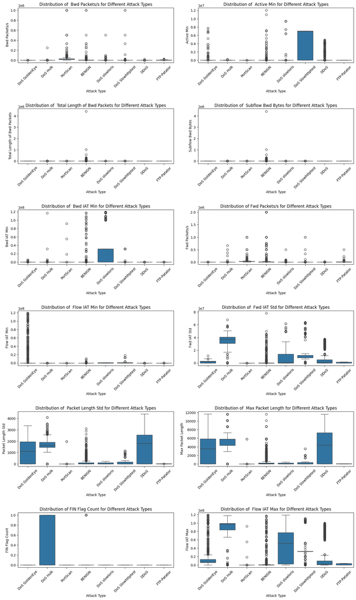

```python
# 4.box plot

# Set up subplots
fig, axes = plt.subplots(nrows=len(features_to_plot)//2 + len(features_to_plot)%2, ncols=2, figsize=(15, 25))

# Flatten the 2D array of subplots
axes = axes.flatten()

# Plot boxplots for each feature
for i, feature in enumerate(features_to_plot):
    sns.boxplot(x=' Label', y=feature, data=dataa, ax=axes[i])
    axes[i].set_title(f'Distribution of {feature} for Different Attack Types')
    axes[i].set_xlabel('Attack Type')
    axes[i].set_ylabel(feature)
    axes[i].tick_params(axis='x', rotation=45)

# Adjust layout to prevent overlap
plt.tight_layout(pad=2.0)  # You can adjust the pad parameter as needed
plt.show()
```

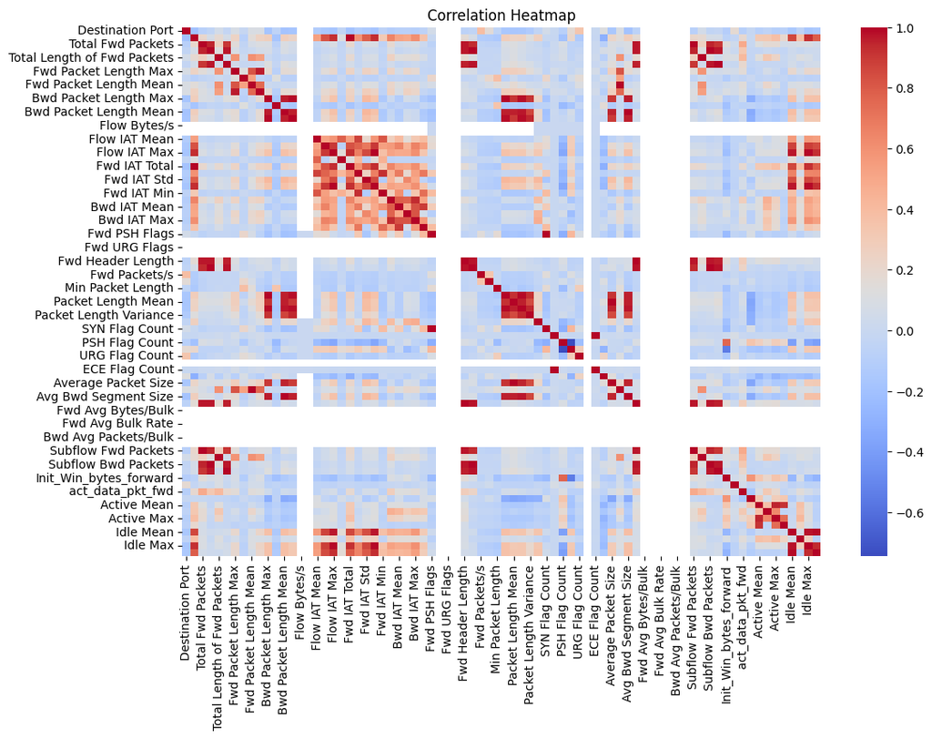

```python
# 5. correlation between each feature

correlation_matrix = dataa.select_dtypes(include='number').corr()
plt.figure(figsize=(12, 8))
sns.heatmap(correlation_matrix, cmap='coolwarm', annot=False)
plt.title('Correlation Heatmap')
plt.show()
```

### Detection and Handling Outliers and Skewness:

```python
# Function to find outliers using IQR method
def find_outliers_iqr(data):
    q1 = np.percentile(data, 25)
    q3 = np.percentile(data, 75)
    iqr = q3 - q1
    lower_bound = q1 - 1.5 * iqr
    upper_bound = q3 + 1.5 * iqr
    outliers = (data < lower_bound) | (data > upper_bound)
    return outliers

num_columns = tf_df.select_dtypes(include=[np.number]).columns

# Looping through numeric columns to find outliers
for col in num_columns:
    outliers = find_outliers_iqr(tf_df[col])
    num_outliers = np.sum(outliers)
    print(f"Number of outliers in {col}: {num_outliers}")
    if num_outliers > 0:
        print(f"Outlier values: {tf_df[col][outliers].unique()}")
    print("=" * 40)
```

[output not shown]

[output cut: 1538 more lines]

[output not shown]

before handling the outliers, let's check skewness and handle them.

```python
tf_df[num_columns].skew()
```

```
 Destination Port                4.079724
 Flow Duration                   0.919337
 Total Fwd Packets             441.101639
 Total Backward Packets        444.883143
Total Length of Fwd Packets    227.352755
                                  ...
 Active Min                      4.190147
Idle Mean                        1.482852
 Idle Std                        5.026635
 Idle Max                        1.258263
 Idle Min                        1.593068
Length: 78, dtype: float64
```

```python
from scipy.stats.mstats import winsorize
import pandas as pd


# Handling outliers and skewness

# Set the percentage of data to be winsorized (e.g., 5% from both tails)
limits = [0.05, 0.05]

# Winsorize each specified column
for column_to_winsorize in num_columns:
    winsorized_data = winsorize(tf_df[column_to_winsorize], limits=limits)
    tf_df[column_to_winsorize] = winsorized_data
tf_df[num_columns].skew()
```

```
 Destination Port              3.537070
 Flow Duration                 0.897388
 Total Fwd Packets             0.875531
 Total Backward Packets        1.530202
Total Length of Fwd Packets    2.634600
                                 ...
 Active Min                    3.707004
Idle Mean                      1.459404
 Idle Std                      2.622314
 Idle Max                      1.233482
 Idle Min                      1.572861
Length: 78, dtype: float64
```

### Scaling the Data

```python
# Scaling the data

from sklearn.preprocessing import MinMaxScaler

columns_to_scale = tf_df.drop(' Label', axis=1).columns

scaler = MinMaxScaler()
tf_df[columns_to_scale] = scaler.fit_transform(tf_df[columns_to_scale])
```

# Feature selection

```python
# 1.Anova Test

#Anova test for removing un important columns:
from scipy.stats import f_oneway
import pandas as pd
import numpy as np

a=dataa
num_columns = a.select_dtypes(include=[np.number]).columns
p_values = {}

for col in num_columns:
    categories = a[' Label'].unique()  # Change ' Label' to 'Label'
    group_data = [a[a[' Label'] == cat][col] for cat in categories]
    f_stat, p_value = f_oneway(*group_data)
    p_values[col] = p_value

# Set a threshold for p-value
p_value_threshold = 0.02

# Filter columns based on p-value threshold
selected_features = [feature for feature, p_value in p_values.items() if p_value < p_value_threshold]

# Create a new DataFrame with selected features
reduced_df = a[selected_features + [' Label']]  # Include the target variable
reduced_df.info()
```

```
<class 'pandas.core.frame.DataFrame'>
Index: 10000 entries, 933411 to 1999982
Data columns (total 65 columns):
 #   Column                        Non-Null Count  Dtype
---  ------                        --------------  -----
 0    Destination Port             10000 non-null  float64
 1    Flow Duration                10000 non-null  float64
 2    Total Fwd Packets            10000 non-null  float64
 3    Total Backward Packets       10000 non-null  float64
 4   Total Length of Fwd Packets   10000 non-null  float64
 5    Total Length of Bwd Packets  10000 non-null  float64
 6    Fwd Packet Length Max        10000 non-null  float64
 7    Fwd Packet Length Min        10000 non-null  float64
 8    Fwd Packet Length Mean       10000 non-null  float64
 9    Fwd Packet Length Std        10000 non-null  float64
```

[output cut: 57 more lines]

```python
# 2. chi2 test
from sklearn.feature_selection import SelectKBest, chi2

X = tf_df.drop(' Label', axis=1)
y = tf_df[' Label']

# Remove features with zero variance
X_filtered = X.loc[:, X.apply(pd.Series.nunique) != 1]

no_of_features= 35
selector = SelectKBest(chi2, k=no_of_features)
X_new = selector.fit_transform(X_filtered, y)

# Get the selected feature indices
selected_feature_indices = selector.get_support()

# Get the column names of the selected features
selected_feature_names = X_filtered.columns[selected_feature_indices]

# Get the chi-squared scores for all features
chi2_scores = selector.scores_

# Create a DataFrame to display feature names and their chi-squared scores
feature_importance_df = pd.DataFrame({'Feature': X_filtered.columns, 'Chi-squared Score': chi2_scores})
feature_importance_df.sort_values(by='Chi-squared Score', ascending=False, inplace=True)

# Print the selected features and their chi-squared scores
print("Selected Features and their Chi-squared Scores:")
feature_importance_df[:no_of_features]
```

```
Selected Features and their Chi-squared Scores:
```

|  | Feature | Chi-squared Score |
| --- | --- | --- |
| 34 | Bwd Packets/s | 1.237099e+06 |
| 60 | Active Min | 1.147814e+06 |
| 29 | Bwd IAT Min | 1.081591e+06 |
| 52 | Subflow Bwd Bytes | 1.078812e+06 |
| 5 | Total Length of Bwd Packets | 1.078812e+06 |
| 57 | Active Mean | 9.832286e+05 |
| 15 | Flow Packets/s | 9.788972e+05 |
| 59 | Active Max | 9.612572e+05 |
| 12 | Bwd Packet Length Mean | 9.351022e+05 |
| 47 | Avg Bwd Segment Size | 9.351022e+05 |
| 33 | Fwd Packets/s | 9.282807e+05 |
| 19 | Flow IAT Min | 8.746710e+05 |
| 22 | Fwd IAT Std | 8.644247e+05 |
| 64 | Idle Min | 8.579592e+05 |
| 62 | Idle Std | 8.377069e+05 |
| 61 | Idle Mean | 8.111813e+05 |
| 10 | Bwd Packet Length Max | 8.049523e+05 |
| 13 | Bwd Packet Length Std | 7.987940e+05 |
| 63 | Idle Max | 7.808768e+05 |
| 38 | Packet Length Std | 7.756368e+05 |
| 36 | Max Packet Length | 7.630018e+05 |
| 23 | Fwd IAT Max | 7.559740e+05 |
| 40 | FIN Flag Count | 7.497651e+05 |
| 11 | Bwd Packet Length Min | 7.495818e+05 |
| 18 | Flow IAT Max | 7.492355e+05 |
| 37 | Packet Length Mean | 7.418109e+05 |
| 45 | Average Packet Size | 7.142774e+05 |
| 35 | Min Packet Length | 7.088340e+05 |
| 26 | Bwd IAT Mean | 7.055052e+05 |
| 17 | Flow IAT Std | 6.977707e+05 |
| 39 | Packet Length Variance | 6.860134e+05 |
| 20 | Fwd IAT Total | 6.789385e+05 |
| 1 | Flow Duration | 6.505760e+05 |
| 7 | Fwd Packet Length Min | 6.313393e+05 |
| 9 | Fwd Packet Length Std | 5.771079e+05 |

```python
# printing list of top 25 features
selected_features=list(feature_importance_df['Feature'][:25])
print(selected_features)
```

```
[' Bwd Packets/s', ' Active Min', ' Bwd IAT Min', ' Subflow Bwd Bytes', ' Total Length of Bwd Packets', 'Active Mean', ' Flow Packets/s', ' Active Max', ' Bwd Packet Length Mean', ' Avg Bwd Segment Size', 'Fwd Packets/s', ' Flow IAT Min', ' Fwd IAT Std', ' Idle Min', ' Idle Std', 'Idle Mean', 'Bwd P…
```

```python
tf_df[' Label'] = tf_df[' Label'].astype(str)
# Perform label encoding
label_encoder = LabelEncoder()
tf_df['Label_encoded'] = label_encoder.fit_transform(tf_df[' Label'])
```

```python
tf_df = tf_df.sample(n=20000, random_state=42)
```

```python
from sklearn.pipeline import make_pipeline
from sklearn.base import BaseEstimator, ClassifierMixin

'''
# Handle missing values using SimpleImputer
pipeline = make_pipeline(SimpleImputer(strategy='mean'), RandomForestClassifier(random_state=42))
'''
#print(cdf[' Label'].dtype)



# Define the features (X) and target variable (y)
X = tf_df[selected_features]                         #.drop([' Label', 'Label_encoded'], axis=1)
y = tf_df['Label_encoded']

# Perform train-test split
X_train, X_test, y_train, y_test = train_test_split(X, y, test_size=0.2, random_state=42)

# Signature-based detection models
signature_models = [
    ('RandomForest', RandomForestClassifier(random_state=42)),   #('GradientBoosting', GradientBoostingClassifier(random_state=42)),
    ('DecisionTree', DecisionTreeClassifier(random_state=42)),
    ('KNeighbors', KNeighborsClassifier()),
                                                            # ('SVM', SVC(probability=True)),
]

# Implementing OneClassSVM a model
class OneClassSVMClassifier(BaseEstimator, ClassifierMixin):
    def __init__(self, nu=0.5, kernel="rbf", gamma="scale"):
        self.model = OneClassSVM(nu=nu, kernel=kernel, gamma=gamma)

    def get_params(self, deep=True):
        return {'nu': self.model.nu, 'kernel': self.model.kernel, 'gamma': self.model.gamma}

    def fit(self, X, y=None):
        self.model.fit(X)
        return self

    def predict(self, X):
        # Convert 1 for outliers and 0 for inliers
        return (self.model.predict(X) == -1).astype(int)

    def predict_proba(self, X):
        # Simulate probability estimates based on the distance from the decision boundary
        decision_function = self.model.decision_function(X)
        proba = (decision_function - decision_function.min()) / (decision_function.max() - decision_function.min())
        # Return probabilities for both classes (inlier and outlier)
        return np.column_stack([1 - proba, proba])

class IsolationForestClassifier(BaseEstimator, ClassifierMixin):
    def __init__(self, contamination=0.1, random_state=None):
        self.contamination = contamination
        self.random_state = random_state
        self.model = IsolationForest(contamination=self.contamination, random_state=self.random_state)

    def fit(self, X, y=None):
        self.model.fit(X)
        return self

    def predict(self, X):
        # Convert 1 for outliers and 0 for inliers
        return (self.model.predict(X) == -1).astype(int)

    def predict_proba(self, X):
        # Simulate probability estimates based on the decision function
        decision_function = self.model.decision_function(X)
        proba = (decision_function - decision_function.min()) / (decision_function.max() - decision_function.min())
        # Return probabilities for both classes (inlier and outlier)
        return np.column_stack([1 - proba, proba])

class EllipticEnvelopeClassifier(BaseEstimator, ClassifierMixin):
    def __init__(self, contamination=0.1):
        self.model = EllipticEnvelope(contamination=contamination)

    def fit(self, X, y=None):
        self.model.fit(X)
        return self

    def predict(self, X):
        # Convert 1 for outliers and 0 for inliers
        return (self.model.predict(X) == -1).astype(int)

    def predict_proba(self, X):
        # Simulate probability estimates based on the decision function
        decision_function = self.model.decision_function(X)
        proba = (decision_function - decision_function.min()) / (decision_function.max() - decision_function.min())
        # Return probabilities for both classes (inlier and outlier)
        return np.column_stack([1 - proba, proba])

# Anomaly-based detection models
anomaly_models = [
    ('OneClassSVM', OneClassSVMClassifier()),
    ('IsolationForest', IsolationForestClassifier(random_state=42)),
    ('EllipticEnvelope', EllipticEnvelopeClassifier()),
                                                        #('LocalOutlierFactor', LocalOutlierFactor()),

]


# Hybrid model (Voting Classifier)
hybrid_model = VotingClassifier(estimators=signature_models + anomaly_models[:-1], voting='hard')

# Train and evaluate signature-based models
for name, model in signature_models:
    model.fit(X_train, y_train)
    y_pred = model.predict(X_test)
    print(f"\n{name}:\n{classification_report(y_test, y_pred)}")

# Train and evaluate anomaly-based models
for name, model in anomaly_models:
    model.fit(X_train)
    y_pred = model.predict(X_test)
    y_pred[y_pred == 1] = 0  # Convert normal class to 0
    y_pred[y_pred == -1] = 1  # Convert anomaly class to 1
    print(f"\n{name}:\n{classification_report(y_test, y_pred)}")

# Train and evaluate hybrid model
hybrid_model.fit(X_train, y_train)
y_pred_hybrid = hybrid_model.predict(X_test)
print(f"\nHybrid Model:\n{classification_report(y_test, y_pred_hybrid)}")
```

```
RandomForest:
              precision    recall  f1-score   support

           0       0.99      0.99      0.99       827
           1       0.99      1.00      1.00       542
           2       0.99      1.00      0.99       387
           3       1.00      0.98      0.99       623
           4       1.00      0.99      1.00       369
           5       1.00      0.99      1.00       367
           6       1.00      1.00      1.00       355
           7       1.00      1.00      1.00       530

    accuracy                           0.99      4000
   macro avg       0.99      0.99      0.99      4000
weighted avg       0.99      0.99      0.99      4000


DecisionTree:
              precision    recall  f1-score   support

           0       0.98      0.99      0.98       827
           1       1.00      1.00      1.00       542
           2       0.98      1.00      0.99       387
           3       1.00      0.98      0.99       623
           4       0.99      0.99      0.99       369
           5       0.99      0.99      0.99       367
           6       1.00      1.00      1.00       355
           7       1.00      1.00      1.00       530

    accuracy                           0.99      4000
   macro avg       0.99      0.99      0.99      4000
weighted avg       0.99      0.99      0.99      4000


KNeighbors:
              precision    recall  f1-score   support

           0       0.95      0.92      0.93       827
           1       0.98      0.97      0.98       542
           2       0.95      0.99      0.97       387
```

[output cut: 62 more lines]

```
Hybrid Model:
              precision    recall  f1-score   support

           0       0.93      1.00      0.96       827
           1       0.98      0.99      0.98       542
           2       0.99      0.99      0.99       387
           3       1.00      0.96      0.98       623
           4       1.00      0.97      0.98       369
           5       1.00      0.96      0.98       367
           6       1.00      0.99      0.99       355
           7       1.00      0.99      1.00       530

    accuracy                           0.98      4000
   macro avg       0.99      0.98      0.98      4000
weighted avg       0.98      0.98      0.98      4000
```

```python
'''# Convert 'float64' to 'float32' and 'int64' to 'int32'
float_columns = cdf.select_dtypes(include=['float64']).columns
int_columns = cdf.select_dtypes(include=['int64']).columns
cdf[float_columns] = cdf[float_columns].astype('float32')
cdf[int_columns] = cdf[int_columns].astype('int32')
'''
```

```
"# Convert 'float64' to 'float32' and 'int64' to 'int32'\nfloat_columns = cdf.select_dtypes(include=['float64']).columns\nint_columns = cdf.select_dtypes(include=['int64']).columns\ncdf[float_columns] = cdf[float_columns].astype('float32')\ncdf[int_columns] = cdf[int_columns].astype('int32')\n"
```

```python
file_path = r"tdf.csv"

# Read the CSV file into a Pandas DataFrame
df = pd.read_csv(file_path)

# Display the first few rows of the DataFrame to verify the import
print(df.head())
df=df.sample(n=50, random_state=42)

import requests
import pandas as pd
import json

# Assuming your DataFrame is named 'df' and the IPv4 addresses are in the 'ipv4' column
ipv4_column = df['ipv4']

# AlienVault OTX API configuration
api_key = '7eeddf89313553770b1cb75c392cd7eef85a514e72eedcb61b79be02f11da5bb'
otx_api_url = 'https://otx.alienvault.com/api/v1/indicators/IPv4/'

for ipv4_address in ipv4_column:
    # Make a GET request to the AlienVault OTX API
    response = requests.get(otx_api_url + ipv4_address, headers={'X-OTX-API-KEY': api_key})

    # Check if the request was successful (status code 200)
    if response.status_code == 200:
        # Beautify and print the JSON response
        formatted_response = json.dumps(response.json(), indent=2)
        print(f"IPv4 Address: {ipv4_address}")
        print("OTX API Response:")
        print(formatted_response)
        print("\n")
    else:
        print(f"Error for IPv4 Address {ipv4_address}. Status Code: {response.status_code}")
```

[output not shown]

[output cut: 45078 more lines]

[output not shown]